# Lab03 A: Matrix Operations and Model Diagnositics

Author

Shiu-Ting Ling

**Handout date:** Monday, March 9, 2026

**FIRM DUE DATA:** Friday, March 27, 2026

**Submission Format:** Submit your lab as R Markdown document `Lab03YourName.rmd` to eLearning’s *SumitLab03* link in the **Labs** folder. Put your name behind the author’s keyword into the header of the YAML header of the Markdown file. Make sure that your R Markdown document renders properly into an `html` document. Otherwise, we will *not* be able to grade your lab!

*This lab counts 9 points towards your final grade.*

Your lab answer has obtained *xx* out of 9 points?

# Part 1: Matrix Operations (3 points)

*For task 1 [a] show your calculations with the intermediate steps using Word’s equation editor. For tasks 1 [b] and [c] show also your R code.*

## Task 1: Manual matrix operations and regression analysis with matrices [1.5 point]

You are given a vector of the dependent variable $\mathbf{y}={(5,8,5,8,5,9)}^T$ and the design matrix
$$\mathbf{X}=\left(\begin{array}{cccccc} 1&1&1&1&1&1\\2&4&2&4&2&6\end{array}\right)^T$$

[a] Enter $\mathbf{y}$ and $\mathbf{X}$ into R. Write your own *R* OLS function using the dependent vector $\mathbf{y}$ and the associated design matrix $\mathbf{X}$ as input. Your function should return the vector of the estimated regression coefficients. (0.5 point)

*Type your answer here.*

### 1-a answer

```r
##
## Custom OLS Function
##
# b = solve(t(X) %*% X) %*% t(X) %*% y
myOLS <- function(X, y) {              # OLS function: takes design matrix X and response y
  b <- solve(t(X) %*% X) %*% t(X) %*% y   # normal equations: b = (X'X)^{-1} X'y
  return(b)
}

## Enter data for task 1[a]
y.a <- matrix(c(5, 8, 5, 8, 5, 9), ncol = 1)   # dependent variable vector (6x1)
x0  <- rep(1, 6)                                 # intercept column of ones
x1  <- c(2, 4, 2, 4, 2, 6)                      # predictor variable
X.a <- cbind(x0, x1)                             # design matrix (6x2)

## Estimate OLS coefficients
(b.a <- myOLS(X.a, y.a))
```

```
   [,1]
x0  3.0
x1  1.1
```

The `myOLS()` function implements the OLS normal equation $\mathbf{b} = (\mathbf{X}^T\mathbf{X})^{-1}\mathbf{X}^T\mathbf{y}$ directly using R matrix operations without relying on `lm()`.

Applied to $\mathbf{y} = (5,8,5,8,5,9)^T$ and the given design matrix, the estimated coefficients are $\hat{b}_0 =$ 3 and $\hat{b}_1 =$ 1.1.

**Calculations** (Same as the intermediate steps using Word’s equation editor in attached Word file):

$$\begin{aligned}
X^TX
&=
\begin{pmatrix}
1 & 1 & 1 & 1 & 1 & 1 \\
2 & 4 & 2 & 4 & 2 & 6
\end{pmatrix}
\begin{pmatrix}
1 & 2 \\
1 & 4 \\
1 & 2 \\
1 & 4 \\
1 & 2 \\
1 & 6
\end{pmatrix} \\
&=
\begin{pmatrix}
1\cdot1 + 1\cdot1 + 1\cdot1 + 1\cdot1 + 1\cdot1 + 1\cdot1 &
1\cdot2 + 1\cdot4 + 1\cdot2 + 1\cdot4 + 1\cdot2 + 1\cdot6 \\
2\cdot1 + 4\cdot1 + 2\cdot1 + 4\cdot1 + 2\cdot1 + 6\cdot1 &
2\cdot2 + 4\cdot4 + 2\cdot2 + 4\cdot4 + 2\cdot2 + 6\cdot6
\end{pmatrix} \\
&=
\begin{pmatrix}
1+1+1+1+1+1 &
2+4+2+4+2+6 \\
2+4+2+4+2+6 &
4+16+4+16+4+36
\end{pmatrix} \\
&=
\begin{pmatrix}
6 & 20 \\
20 & 80
\end{pmatrix}
\end{aligned}
\begin{aligned}
X^Ty
&=
\begin{pmatrix}
1 & 1 & 1 & 1 & 1 & 1 \\
2 & 4 & 2 & 4 & 2 & 6
\end{pmatrix}
\begin{pmatrix}
5 \\
8 \\
5 \\
8 \\
5 \\
9
\end{pmatrix} \\
&=
\begin{pmatrix}
1\cdot5 + 1\cdot8 + 1\cdot5 + 1\cdot8 + 1\cdot5 + 1\cdot9 \\
2\cdot5 + 4\cdot8 + 2\cdot5 + 4\cdot8 + 2\cdot5 + 6\cdot9
\end{pmatrix} \\
&=
\begin{pmatrix}
5+8+5+8+5+9 \\
10+32+10+32+10+54
\end{pmatrix} \\
&=
\begin{pmatrix}
40 \\
148
\end{pmatrix}
\end{aligned}
\begin{aligned}
(X^TX)^{-1}
&=
\frac{1}{6\cdot80 - 20\cdot20}
\begin{pmatrix}
80 & -20 \\
-20 & 6
\end{pmatrix} \\
&=
\frac{1}{80}
\begin{pmatrix}
80 & -20 \\
-20 & 6
\end{pmatrix} \\
&=
\begin{pmatrix}
1 & -0.25 \\
-0.25 & 0.075
\end{pmatrix}
\end{aligned}
\begin{aligned}
b
&=
(X^TX)^{-1} X^Ty \\
&=
\begin{pmatrix}
1 & -0.25 \\
-0.25 & 0.075
\end{pmatrix}
\begin{pmatrix}
40 \\
148
\end{pmatrix} \\
&=
\begin{pmatrix}
40 - 37 \\
-10 + 11.1
\end{pmatrix} \\
&=
\begin{pmatrix}
3 \\
1.1
\end{pmatrix}
\end{aligned}$$

[b] Use *R*’s matrix operations to calculate for a dependent variable $\mathbf{y}={(5,8,9)}^T$, the design matrix
$$\mathbf{X}=\left(\begin{matrix}1&1&1\\2&4&6\\\end{matrix}\right)^T$$
and the diagonal weights matrix
$$\mathbf{W}=\left(\begin{matrix}3&0&0\\0&2&0\\0&0&1\\\end{matrix}\right)$$
the weighted regression coefficients with the formula $\mathbf{b}_w=\left(\mathbf{X}^T\cdot\mathbf{W}\cdot\mathbf{X}\right)^{-1}\cdot\mathbf{X}^T\cdot\mathbf{W}\cdot\mathbf{y}$. (0.5 points)

*Type your answer here.*

### 1-b answer

```r
##
## Weighted Regression
##

## Enter data for task 1[b]
y.b <- matrix(c(5, 8, 9), ncol = 1)             # dependent variable vector (3x1)
x0b <- rep(1, 3)                                 # constant 1 intercept vector
x1b <- c(2, 4, 6)                                # predictor variable
X.b <- cbind(x0b, x1b)                           # design matrix (3x2)
W   <- diag(c(3, 2, 1))                          # diagonal weight matrix (3x3)

## Weighted regression following b_w = (X'WX)^{-1} X'Wy
tXWX    <- t(X.b) %*% W %*% X.b                 # cross-product matrix X'WX (2x2)
tXWXInv <- solve(tXWX)                           # inverse of X'WX
tXWy    <- t(X.b) %*% W %*% y.b                 # right-hand side X'Wy (2x1)
(b.w    <- tXWXInv %*% tXWy)                     # weighted regression coefficients
```

```
    [,1]
x0b  3.0
x1b  1.1
```

Using the weighted regression formula $\mathbf{b}_w = (\mathbf{X}^T\mathbf{W}\mathbf{X})^{-1}\mathbf{X}^T\mathbf{W}\mathbf{y}$, the estimated coefficients for the three-observation problem with $\mathbf{W} = \text{diag}(3,2,1)$ are $\hat{b}_{w0} =$ 3 and $\hat{b}_{w1} =$ 1.1.

[c] Compare the estimated regression coefficients from task 1 [b] with those from task 1 [c]. Explain why they are identically. Hint: You may see the effect of the weights matrix $\mathbf{W}$ by running the estimation equation step-by-step one intermediate result at a time. (0.5 points)

*Type your answer here.*

### 1-c answer

```r
##
## Comparison of [a] and [b]
##
all.equal(b.a, b.w, check.attributes = FALSE)
```

```
[1] TRUE
```

```r
## Inspect why: X'WX from [b] equals X'X from [a]
cat("X'WX from [b]:\n"); print(tXWX)
```

```
X'WX from [b]:
```

```
    x0b x1b
x0b   6  20
x1b  20  80
```

```r
cat("X'X  from [a]:\n"); print(t(X.a) %*% X.a)
```

```
X'X  from [a]:
```

```
   x0 x1
x0  6 20
x1 20 80
```

```r
## Inspect why: X'Wy from [b] equals X'y from [a]
cat("X'Wy from [b]:\n"); print(tXWy)
```

```
X'Wy from [b]:
```

```
    [,1]
x0b   40
x1b  148
```

```r
cat("X'y  from [a]:\n"); print(t(X.a) %*% y.a)
```

```
X'y  from [a]:
```

```
   [,1]
x0   40
x1  148
```

The two sets of estimated coefficients are numerically identical, as confirmed by `all.equal()` returning `TRUE`. Inspecting the intermediate results reveals why. In task 1[a], the six-row design matrix contains only three *distinct* rows: observation $(x=2, y=5)$ appears 3 times, $(x=4, y=8)$ appears 2 times, and $(x=6, y=9)$ appears 1 time. In task 1[b], the weights matrix $\mathbf{W} = \text{diag}($ 3 $,$ 2 $,$ 1$)$ assigns exactly these repetition counts as weights to the three unique observations.

As a result, the two cross-product matrices are identical:
$$\mathbf{X}^T\mathbf{W}\mathbf{X} = \mathbf{X}^T\mathbf{X} =
\begin{pmatrix} 6 & 20 \\ 20 & 80 \end{pmatrix}$$

and so are the right-hand side vectors:
$$\mathbf{X}^T\mathbf{W}\mathbf{y} = \mathbf{X}^T\mathbf{y} =
\begin{pmatrix} 40 \\ 148 \end{pmatrix}$$

Since both inputs to the normal equations are identical, the resulting coefficient estimates must also be the same. This illustrates a general principle: a weighted regression on $n$ unique observations is equivalent to an unweighted regression on the full repeated dataset, where each weight represents how many times that observation appears.

## Task 2: Coding schemes of categorical variables (1.5 points)

Provide the *R* syntax code of your answers. You can either use the `lm(…)` or your coded ordinary least squares function for this task.

[a] Enter the $9\times1$ matrix $\mathbf{y}$ and the $9\times3$ design matrices $\mathbf{X}_1$ to $\mathbf{X}_4$ separate matrix objects into *R* and show these object in your answer (0.25 points):
$$\mathbf{y}=\left[\begin{array}{c}7\\5\\3\\2\\3\\4\\9\\5\\7\end{array}\right] \;
\mathbf{X}_1= \left[ \begin{array}{ccc}1&0&0\\1&0&0\\1&0&0\\1&1&0\\1&1&0\\1&1&0\\1&0&1\\1&0&1\\1&0&1\end{array} \right] \;
\mathbf{X}_2=\left[\begin{array}{ccc}1&1&0\\1&1&0\\1&1&0\\1&0&0\\1&0&0\\1&0&0\\1&0&1\\1&0&1\\1&0&1\end{array}\right] \;
\mathbf{X}_3=\left[\begin{array}{ccc}1&-1&-1\\1&-1&-1\\1&-1&-1\\1&1&0\\1&1&0\\1&1&0\\1&0&1\\1&0&1\\1&0&1\end{array}\right] \;
\mathbf{X}_4=\left[\begin{array}{ccc}1&1&0\\1&1&0\\1&1&0\\1&-1&-1\\1&-1&-1\\1&-1&-1\\1&0&1\\1&0&1\\1&0&1\end{array}\right]$$

$\mathbf{X}_1$ and $\mathbf{X}_2$ are given in the *indicator coding scheme* (*R* codes it as `contrasts(factor) <- "contr.treatment"`) whereas $\mathbf{X}_3$ and $\mathbf{X}_4$ are given in the *centered coding scheme* (*R* codes it as `contrasts(factor) <- "contr.sum"` and Hamilton p 99 calls it *effect coding*). In $\mathbf{X}_1$ and $\mathbf{X}_3$ the second category is suppressed, whereas in $\mathbf{X}_2$ and $\mathbf{X}_4$ the last category is suppressed due to the redundancy among a full set of indicator variables.

*Type your answer here.*

### 2-a answer

```r
## Setup
y   <- c(7,5,3, 2,3,4, 9,5,7)
grp <- factor(rep(c("g1","g2","g3"), each=3))          # 3 obs per group

## X1: indicator coding, g1 = reference
contrasts(grp) <- "contr.treatment"
contrasts(grp)                                         # g1 suppressed (reference)
```

```
   g2 g3
g1  0  0
g2  1  0
g3  0  1
```

```r
mod1 <- lm(y ~ grp)
(X1  <- model.matrix(mod1))
```

```
  (Intercept) grpg2 grpg3
1           1     0     0
2           1     0     0
3           1     0     0
4           1     1     0
5           1     1     0
6           1     1     0
7           1     0     1
8           1     0     1
9           1     0     1
attr(,"assign")
[1] 0 1 1
attr(,"contrasts")
attr(,"contrasts")$grp
[1] "contr.treatment"
```

```r
## X2: indicator coding, g2 = reference
grp <- relevel(grp, ref="g2")
contrasts(grp) <- "contr.treatment"
contrasts(grp)                                         # g2 suppressed (reference)
```

```
   g1 g3
g2  0  0
g1  1  0
g3  0  1
```

```r
mod2 <- lm(y ~ grp)
(X2  <- model.matrix(mod2))
```

```
  (Intercept) grpg1 grpg3
1           1     1     0
2           1     1     0
3           1     1     0
4           1     0     0
5           1     0     0
6           1     0     0
7           1     0     1
8           1     0     1
9           1     0     1
attr(,"assign")
[1] 0 1 1
attr(,"contrasts")
attr(,"contrasts")$grp
[1] "contr.treatment"
```

```r
## X3: effect coding, g1 = suppressed
## contr.sum always suppresses the LAST level → put g1 last
grp <- factor(grp, levels=c("g2","g3","g1"))           # put g1 last → g1 will be suppressed
contrasts(grp) <- "contr.sum"
contrasts(grp)                                         # g1 row = (-1,-1)
```

```
   [,1] [,2]
g2    1    0
g3    0    1
g1   -1   -1
```

```r
mod3 <- lm(y ~ grp)
(X3  <- model.matrix(mod3))
```

```
  (Intercept) grp1 grp2
1           1   -1   -1
2           1   -1   -1
3           1   -1   -1
4           1    1    0
5           1    1    0
6           1    1    0
7           1    0    1
8           1    0    1
9           1    0    1
attr(,"assign")
[1] 0 1 1
attr(,"contrasts")
attr(,"contrasts")$grp
[1] "contr.sum"
```

```r
## X4: effect coding, g2 = suppressed
## contr.sum always suppresses the LAST level → put g2 last
grp <- factor(grp, levels=c("g1","g3","g2"))           # put g2 last → g2 will be suppressed
contrasts(grp) <- "contr.sum"
contrasts(grp)                                         # g2 row = (-1,-1)
```

```
   [,1] [,2]
g1    1    0
g3    0    1
g2   -1   -1
```

```r
mod4 <- lm(y ~ grp)
(X4  <- model.matrix(mod4))
```

```
  (Intercept) grp1 grp2
1           1    1    0
2           1    1    0
3           1    1    0
4           1   -1   -1
5           1   -1   -1
6           1   -1   -1
7           1    0    1
8           1    0    1
9           1    0    1
attr(,"assign")
[1] 0 1 1
attr(,"contrasts")
attr(,"contrasts")$grp
[1] "contr.sum"
```

[b] Give the three group means ${\bar{y}}_{g_1}$, ${\bar{y}}_{g_2}$ and ${\bar{y}}_{g_3}$ either manually or with *R* of the observation groups $g_1=\left\{y_1,y_2,y_3\right\}$, $g_2=\left\{y_4,y_5,y_6\right\}$ and $g_3=\left\{y_7,y_8,y_9\right\}$ as well as the global mean ${\bar{y}}_{global}$ for all observations $\left\{y_1,\ldots,y_9\right\}$. (0.25 points)

*Type your answer here.*

### 2-b answer

```r
## Group means and global mean
(ybar.g1     <- mean(y[1:3]))
```

```
[1] 5
```

```r
(ybar.g2     <- mean(y[4:6]))
```

```
[1] 3
```

```r
(ybar.g3     <- mean(y[7:9]))
```

```
[1] 7
```

```r
(ybar.global <- mean(y))
```

```
[1] 5
```

The group means ${\bar{y}}_{g_1}$ is 5.

The group means ${\bar{y}}_{g_2}$ is 3.

The group means ${\bar{y}}_{g_3}$ is 7.

The global mean ${\bar{y}}_{global}$ is 5.

[c] Find the four sets of estimated regression coefficients for the intercept $b_0$ and group coefficients $b_{g_1}$ or $b_{g_2}$ and $b_{g_3}$ by regressing $\mathbf{y}$ on the four design matrices $\mathbf{X}_1$, $\mathbf{X}_2$, $\mathbf{X}_3$ and $\mathbf{X}_4$ with your linear regression function that you have developed in task 1 [a] and enter these estimates into the table below. (0.25 points)

**Hints:** (i) in the centered coding scheme the coefficient for the missing category can be calculated as the negative sum of the two other estimated group parameters, for example, $b_{g_1}=-\left(b_{g_2}+b_{g_3}\right)$. (ii) For the cornered coding schemes `y~X1` and `y~X2`, the values or terms for the dashed cells cannot be calculated from the regression results.

### 2-c answer

```r
## Coefficients using myOLS from Task 1[a]
y.mat <- matrix(y, ncol=1)                             # convert y to matrix for myOLS

(b1 <- myOLS(X1, y.mat))                               # b0, b_g2, b_g3
```

```
            [,1]
(Intercept)    5
grpg2         -2
grpg3          2
```

```r
(b2 <- myOLS(X2, y.mat))                               # b0, b_g1, b_g3
```

```
            [,1]
(Intercept)    3
grpg1          2
grpg3          4
```

```r
(b3 <- myOLS(X3, y.mat))                               # b0, b_g2, b_g3
```

```
            [,1]
(Intercept)    5
grp1          -2
grp2           2
```

```r
(bg1.X3 <- -(b3[2] + b3[3]))                           # b_g1 = -(b_g2 + b_g3)
```

```
[1] 4.440892e-16
```

```r
(b4 <- myOLS(X4, y.mat))                               # b0, b_g1, b_g3
```

```
                     [,1]
(Intercept)  5.000000e+00
grp1        -2.220446e-16
grp2         2.000000e+00
```

```r
(bg2.X4 <- -(b4[2] + b4[3]))                           # b_g2 = -(b_g1 + b_g3)
```

```
[1] -2
```

| Model: | $b_0$ | $b_{g_1}$ | $b_{g_2}$ | $b_{g_3}$ |
| --- | --- | --- | --- | --- |
| `y~X1` | 5 | — | -2 | +2 |
| `y~X2` | 3 | +2 | — | +4 |
| `y~X3` | 5 | 0 | -2 | +2 |
| `y~X4` | 5 | 0 | -2 | +2 |

[d] For each design matrix the global mean ${\bar{y}}_{global}$ and group means ${\bar{y}}_{g_1}$, ${\bar{y}}_{g_2}$ and ${\bar{y}}_{g_3}$ can also be expressed as a function of the estimated regression coefficients $b_0$, $b_{g_1}$, $b_{g_2}$ and/or $b_{g_3}$ Find the expressions for the means in terms of the regression parameters and enter these expressions into the table below. (0.5 point)

### 2-d answer

| Model: | $\bar{y}_{global}$ | $\bar{y}_{g_1}$ | $\bar{y}_{g_2}$ | $\bar{y}_{g_3}$ |
| --- | --- | --- | --- | --- |
| `y~X1` | — | $b_0$ | $b_0 + b_{g_2}$ | $b_0 + b_{g_3}$ |
| `y~X2` | — | $b_0 + b_{g_1}$ | $b_0$ | $b_0 + b_{g_3}$ |
| `y~X3` | $b_0$ | $b_0 + b_{g_1}$ | $b_0 + b_{g_2}$ | $b_0 + b_{g_3}$ |
| `y~X4` | $b_0$ | $b_0 + b_{g_1}$ | $b_0 + b_{g_2}$ | $b_0 + b_{g_3}$ |

[e] Which coding scheme has a more *intuitive* interpretation? Justify your answer. (0.25 points)

*Type your answer here.*

### 2-e answer

The effect coding scheme (`contr.sum`) has a more intuitive interpretation. In this scheme, the intercept b0 equals the global mean of all observations, and each group coefficient $b_{g_j}$ represents the deviation of that group’s mean from the global mean. This interpretation does not depend on an arbitrarily chosen reference category, making it easier to understand each group’s performance relative to the overall average. In contrast, indicator coding sets b0 equal to the mean of the reference group, so the interpretation of all other coefficients changes depending on which group is chosen as the reference.

# Part 2: Coordinate Transformations (1.5 points)

## Task 3: Rubber sheeting (1.5 points)

You will be following up on the `ArbitraryToTarget.R` example from `Week06` channel and use its data `ArbitraryToTarget.Rdata`. However, instead of using the *Procrustes* procedure to match both point configuration you will be using linear regression for the x- and y-coordinates.

[a] Match both configurations into the target coordinate system using linear regression with a polynomial of 1<sup>st</sup> order. Show the plot of both configurations in the target coordinate system and the residual vector plot. (0.5 points)

*Show the R code, results and plots here.*

### 3-a answer

```r
##
## Rubber Sheeting – 1st Order Polynomial Regression
##
## Load data
load("ArbitraryToTarget.Rdata")


## Data setup
Y     <- as.matrix(targetFrame[targetFrame[,3], 1:2])   # Target control points
X     <- as.matrix(sourceFrame[sourceFrame[,3], 1:2])   # Arbitrary control points
X.all <- as.matrix(sourceFrame[, 1:2])                  # All arbitrary points

## Assemble data frames for lm()
## Control points only → used for fitting
ctrl.df <- data.frame(xt = Y[,"x"], yt = Y[,"y"],
                      xa = X[,"x"], ya = X[,"y"])

## All source points → used for prediction
all.df  <- data.frame(xa = X.all[,"x"], ya = X.all[,"y"])

## 1st Order Polynomial Regression
## x_target = b0x + b1x*xa + b2x*ya
## y_target = b0y + b1y*xa + b2y*ya
lm1.x <- lm(xt ~ xa + ya, data = ctrl.df)
lm1.y <- lm(yt ~ xa + ya, data = ctrl.df)

cat("=== 1st Order Polynomial: x-coordinate regression ===\n")
```

```
=== 1st Order Polynomial: x-coordinate regression ===
```

```r
print(summary(lm1.x))
```

```
Call:
lm(formula = xt ~ xa + ya, data = ctrl.df)

Residuals:
       1        2        3        4        5        6        7        8
-0.12947  0.14342  0.29996 -0.12949 -0.11537  0.07611  0.03006 -0.17522

Coefficients:
            Estimate Std. Error t value Pr(>|t|)
(Intercept)  1.30199    1.49596   0.870  0.42392
xa           0.35355    0.05581   6.335  0.00145 **
ya           0.10975    0.04304   2.550  0.05127 .
---
Signif. codes:  0 '***' 0.001 '**' 0.01 '*' 0.05 '.' 0.1 ' ' 1

Residual standard error: 0.1974 on 5 degrees of freedom
Multiple R-squared:  0.9229,    Adjusted R-squared:  0.892
F-statistic: 29.92 on 2 and 5 DF,  p-value: 0.001651
```

```r
cat("=== 1st Order Polynomial: y-coordinate regression ===\n")
```

```
=== 1st Order Polynomial: y-coordinate regression ===
```

```r
print(summary(lm1.y))
```

```
Call:
lm(formula = yt ~ xa + ya, data = ctrl.df)

Residuals:
        1         2         3         4         5         6         7         8
 0.051903 -0.256137  0.151320 -0.284227 -0.005052  0.124172  0.058985  0.159035

Coefficients:
            Estimate Std. Error t value Pr(>|t|)
(Intercept) -0.83405    1.57607  -0.529 0.619313
xa          -0.22090    0.05880  -3.757 0.013199 *
ya           0.44168    0.04534   9.740 0.000194 ***
---
Signif. codes:  0 '***' 0.001 '**' 0.01 '*' 0.05 '.' 0.1 ' ' 1

Residual standard error: 0.2079 on 5 degrees of freedom
Multiple R-squared:   0.99, Adjusted R-squared:  0.986
F-statistic: 246.9 on 2 and 5 DF,  p-value: 1.006e-05
```

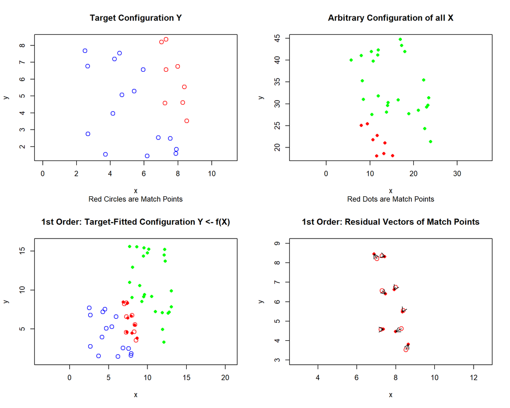

```r
## Transform ALL arbitrary points into target coordinate system
X.fit1 <- cbind(x = predict(lm1.x, newdata = all.df),
                y = predict(lm1.y, newdata = all.df))

## Plots
layout(matrix(c(1,2,3,4), ncol=2, nrow=2, byrow=T))

  ## Panel 1: Target configuration
  plot(targetFrame$x, targetFrame$y,
       col=ifelse(targetFrame$cPts,"red","blue"), cex=1.3, asp=1,
       xlab="x", ylab="y", main="Target Configuration Y",
       sub="Red Circles are Match Points")

  ## Panel 2: Original arbitrary configuration
  plot(sourceFrame$x, sourceFrame$y,
       col=ifelse(sourceFrame$cPts,"red","green"), pch=16, asp=1,
       xlab="x", ylab="y", main="Arbitrary Configuration of all X",
       sub="Red Dots are Match Points")

  ## Panel 3: Both in target coordinate system
  plot(targetFrame$x, targetFrame$y,
       col=ifelse(targetFrame$cPts,"red","blue"), cex=1.3, asp=1,
       xlim=c(1,16), ylim=c(1,16),
       xlab="x", ylab="y",
       main="1st Order: Target-Fitted Configuration Y <- f(X)")
  points(X.fit1, col=ifelse(sourceFrame$cPts,"red","green"), pch=16)

  ## Panel 4: Residual vectors at control points
  plot(Y, col="red", cex=1.3, asp=1,
       xlim=c(6.5,9), ylim=c(3,9),
       xlab="x", ylab="y",
       main="1st Order: Residual Vectors of Match Points")
  points(X.fit1[sourceFrame$cPts,], col="red", pch=16)
  arrows(Y[,1], Y[,2],
         X.fit1[sourceFrame$cPts,1], X.fit1[sourceFrame$cPts,2],
         code=2, length=0.1)
```

```r
layout(matrix(1))   # reset plot surface
```

To match the arbitrary coordinate configuration into the target coordinate system, I fitted two separate first-order polynomial regression models — one for the x-coordinate and one for the y-coordinate — using the 8 control points that appear in both configurations:

$$x_t = b_{0,x} + b_{1,x} \cdot x_a + b_{2,x} \cdot y_a$$
$$y_t = b_{0,y} + b_{1,y} \cdot x_a + b_{2,y} \cdot y_a$$

For the x-coordinate regression, the predictor $x_a$ is strongly significant (p = `0.0014`), while $y_a$ is only marginally significant (p = `0.0513`), just above the conventional 0.05 threshold. The model nonetheless explains `89.2`% of the variance in the target x-coordinates (adjusted R² = `0.892`), and the global F-test is significant (p = `0.0017`). For the y-coordinate regression, both predictors $x_a$ and $y_a$ are statistically significant (p = `0.0132` and p = `2\times 10^{-4}`, respectively), and the model achieves a higher goodness-of-fit with adjusted R² = `0.986` and a highly significant global F-test (p = `1.01e-05`).

The upper-left panel shows the target configuration, where red circles mark the 8 control points shared between both coordinate systems. The upper-right panel shows the original arbitrary configuration, which has a very different scale and orientation compared to the target. After applying the first-order regression transformation, the fitted source points are placed into the target coordinate space as shown in the lower-left panel. Note that the blue points (target) and the green points (transformed source) represent different locations and are therefore not expected to spatially coincide — they simply belong to two different point sets measured in the same coordinate system. The alignment quality is evaluated only through the red control points, which appear to overlap closely in the lower-left panel.

The residual vector plot in the lower-right panel zooms in on the 8 control points and shows the displacement between each control point’s predicted position and its actual target position. The arrows are generally short, suggesting that the first-order polynomial transformation aligns the two coordinate systems reasonably well at the control point locations.

[b] Match both configurations into the target coordinate system using linear regression with a polynomial of 2<sup>nd</sup> order. Show the plot of both configurations in the target coordinate system and the residual vector plot. (0.5 points)

*Show the R code, results and plots here.*

### 3-b answer

```r
##
## Rubber Sheeting – 2nd Order Polynomial Regression
##

## Data setup: same as Task 3[a]
## Y, X, X.all, ctrl.df, all.df already defined in Task 3[a]

## 2nd Order Polynomial Regression
## x_target = b0x + b1x*xa + b2x*ya + b3x*xa^2 + b4x*xa*ya + b5x*ya^2
## y_target = b0y + b1y*xa + b2y*ya + b3y*xa^2 + b4y*xa*ya + b5y*ya^2
lm2.x <- lm(xt ~ xa + ya + I(xa^2) + I(xa*ya) + I(ya^2), data = ctrl.df)
lm2.y <- lm(yt ~ xa + ya + I(xa^2) + I(xa*ya) + I(ya^2), data = ctrl.df)

cat("=== 2nd Order Polynomial: x-coordinate regression ===\n")
```

```
=== 2nd Order Polynomial: x-coordinate regression ===
```

```r
print(summary(lm2.x))
```

```
Call:
lm(formula = xt ~ xa + ya + I(xa^2) + I(xa * ya) + I(ya^2), data = ctrl.df)

Residuals:
       1        2        3        4        5        6        7        8
-0.10366  0.12629  0.19646 -0.13615 -0.01982  0.08995  0.09639 -0.24946

Coefficients:
             Estimate Std. Error t value Pr(>|t|)
(Intercept) -29.78083   51.94420  -0.573    0.624
xa            2.67152    4.18964   0.638    0.589
ya            1.81359    2.80123   0.647    0.584
I(xa^2)      -0.04335    0.08542  -0.507    0.662
I(xa * ya)   -0.06272    0.10696  -0.586    0.617
I(ya^2)      -0.02356    0.04079  -0.578    0.622

Residual standard error: 0.2862 on 2 degrees of freedom
Multiple R-squared:  0.9351,    Adjusted R-squared:  0.773
F-statistic: 5.767 on 5 and 2 DF,  p-value: 0.1544
```

```r
cat("=== 2nd Order Polynomial: y-coordinate regression ===\n")
```

```
=== 2nd Order Polynomial: y-coordinate regression ===
```

```r
print(summary(lm2.y))
```

```
Call:
lm(formula = yt ~ xa + ya + I(xa^2) + I(xa * ya) + I(ya^2), data = ctrl.df)

Residuals:
        1         2         3         4         5         6         7         8
 0.009965  0.003734  0.022924 -0.023152 -0.005406 -0.049041  0.044553 -0.003577

Coefficients:
              Estimate Std. Error t value Pr(>|t|)
(Intercept) -30.673044   9.609333  -3.192   0.0857 .
xa            2.510422   0.775056   3.239   0.0835 .
ya            1.767641   0.518208   3.411   0.0762 .
I(xa^2)      -0.070365   0.015803  -4.453   0.0469 *
I(xa * ya)   -0.051224   0.019787  -2.589   0.1224
I(ya^2)      -0.017095   0.007545  -2.266   0.1517
---
Signif. codes:  0 '***' 0.001 '**' 0.01 '*' 0.05 '.' 0.1 ' ' 1

Residual standard error: 0.05295 on 2 degrees of freedom
Multiple R-squared:  0.9997,    Adjusted R-squared:  0.9991
F-statistic:  1538 on 5 and 2 DF,  p-value: 0.0006498
```

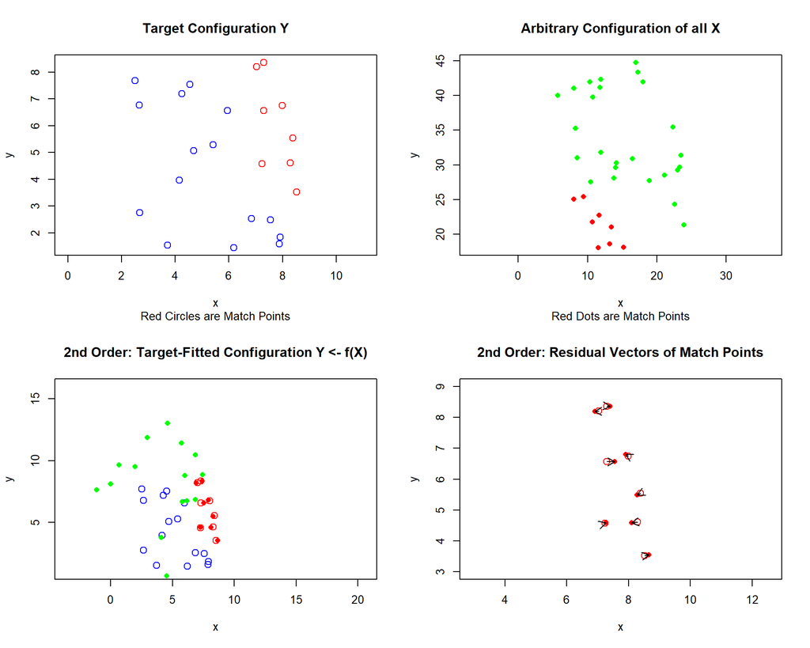

```r
## Transform ALL arbitrary points into target coordinate system
X.fit2 <- cbind(x = predict(lm2.x, newdata = all.df),
                y = predict(lm2.y, newdata = all.df))

## Plots
layout(matrix(c(1,2,3,4), ncol=2, nrow=2, byrow=T))

  ## Panel 1: Target configuration
  plot(targetFrame$x, targetFrame$y,
       col=ifelse(targetFrame$cPts,"red","blue"), cex=1.3, asp=1,
       xlab="x", ylab="y", main="Target Configuration Y",
       sub="Red Circles are Match Points")

  ## Panel 2: Original arbitrary configuration
  plot(sourceFrame$x, sourceFrame$y,
       col=ifelse(sourceFrame$cPts,"red","green"), pch=16, asp=1,
       xlab="x", ylab="y", main="Arbitrary Configuration of all X",
       sub="Red Dots are Match Points")

  ## Panel 3: Both in target coordinate system
  plot(targetFrame$x, targetFrame$y,
       col=ifelse(targetFrame$cPts,"red","blue"), cex=1.3, asp=1,
       xlim=c(1,16), ylim=c(1,16),
       xlab="x", ylab="y",
       main="2nd Order: Target-Fitted Configuration Y <- f(X)")
  points(X.fit2, col=ifelse(sourceFrame$cPts,"red","green"), pch=16)

  ## Panel 4: Residual vectors at control points
  plot(Y, col="red", cex=1.3, asp=1,
       xlim=c(6.5,9), ylim=c(3,9),
       xlab="x", ylab="y",
       main="2nd Order: Residual Vectors of Match Points")
  points(X.fit2[sourceFrame$cPts,], col="red", pch=16)
  arrows(Y[,1], Y[,2],
         X.fit2[sourceFrame$cPts,1], X.fit2[sourceFrame$cPts,2],
         code=2, length=0.1)
```

```r
layout(matrix(1))   # reset plot surface
```

To allow for a more flexible transformation, I extended the regression models to a second-order polynomial by adding three quadratic terms — $x_a^2$, $x_a \cdot y_a$, and $y_a^2$ — to each coordinate equation:

$$x_t = b_{0,x} + b_{1,x} \cdot x_a + b_{2,x} \cdot y_a + b_{3,x} \cdot x_a^2 + b_{4,x} \cdot x_a y_a + b_{5,x} \cdot y_a^2$$
$$y_t = b_{0,y} + b_{1,y} \cdot x_a + b_{2,y} \cdot y_a + b_{3,y} \cdot x_a^2 + b_{4,y} \cdot x_a y_a + b_{5,y} \cdot y_a^2$$

For the x-coordinate regression, none of the individual coefficients are statistically significant at the 0.05 level, and the global F-test is also not significant (p = `0.1544`). The Adjusted R² is `0.773`, which is actually lower than the first-order model, suggesting that the additional quadratic terms do not improve the fit for the x-coordinate. For the y-coordinate regression, only the term $x_a^2$ reaches significance (p = `0.0469`), while the other terms remain non-significant. However, the global F-test is highly significant (p = `6.5e-04`), and the Adjusted R² increases to `0.999`, indicating a substantially better fit compared to the first-order model.

[c] Perform a partial F-test for the x- and y-coordinates regression equation to decide whether a 1<sup>st</sup> or 2<sup>nd</sup> polynomial is appropriate for either/and the x- and y-coordinates. Comment on the results. (0.5 points)

*Show the R code, results and plots here.*

### 3-c answer

```r
##
## Partial F-test – 1st vs 2nd Order Polynomial
##

## Partial F-test for x-coordinate
## H0: the three quadratic terms (xa^2, xa*ya, ya^2) add nothing to the x model
cat("=== Partial F-test: x-coordinate (1st vs 2nd order) ===\n")
```

```
=== Partial F-test: x-coordinate (1st vs 2nd order) ===
```

```r
(pFtest.x <- anova(lm1.x, lm2.x))
```

```
Analysis of Variance Table

Model 1: xt ~ xa + ya
Model 2: xt ~ xa + ya + I(xa^2) + I(xa * ya) + I(ya^2)
  Res.Df     RSS Df Sum of Sq      F Pr(>F)
1      5 0.19478
2      2 0.16383  3  0.030947 0.1259 0.9367
```

```r
## Partial F-test for y-coordinate
## H0: the three quadratic terms (xa^2, xa*ya, ya^2) add nothing to the y model
cat("=== Partial F-test: y-coordinate (1st vs 2nd order) ===\n")
```

```
=== Partial F-test: y-coordinate (1st vs 2nd order) ===
```

```r
(pFtest.y <- anova(lm1.y, lm2.y))
```

```
Analysis of Variance Table

Model 1: yt ~ xa + ya
Model 2: yt ~ xa + ya + I(xa^2) + I(xa * ya) + I(ya^2)
  Res.Df      RSS Df Sum of Sq     F  Pr(>F)
1      5 0.216198
2      2 0.005607  3   0.21059 25.04 0.03865 *
---
Signif. codes:  0 '***' 0.001 '**' 0.01 '*' 0.05 '.' 0.1 ' ' 1
```

To decide whether the additional quadratic terms improve the coordinate transformation, a partial F-test was performed for each coordinate direction separately. The restricted model (1st order) and the full model (2nd order) are nested, which makes the partial F-test applicable. The null hypothesis in each case is that the three quadratic terms — $x_a^2$, $x_a \cdot y_a$, and $y_a^2$ — jointly contribute nothing beyond what the first-order terms already explain.

For the **x-coordinate**, the partial F-test yields F = `0.1259` with p = `0.9367`, which is far from significant. This means the three quadratic terms do not provide a meaningful improvement for predicting the x-coordinate, and the simpler **1st order polynomial is sufficient**.

For the **y-coordinate**, the partial F-test yields F = `25.0403` with p = `0.0386`, which is significant at the 0.05 level. This indicates that the quadratic terms collectively contribute a significant improvement for predicting the y-coordinate, and the **2nd order polynomial is more appropriate**.

In summary, the two coordinate directions call for different polynomial orders: a 1st order polynomial is adequate for the x-coordinate transformation, while a 2nd order polynomial is needed for the y-coordinate transformation. This suggests that the relationship between the arbitrary and target coordinates is more complex in the y-dimension than in the x-dimension.

# Part 3: Model Building and Diagnostics (4.5 points)

Open the `CPS1985` data-frame with `data("CPS1985",package="AER")`. Assign new row-names with the statement `rownames(CPS1985) <- 1:nrow(CPS1985)` to the data-frame. Study the definitions of the variable in the associated online help.

```r
# ?CPS1985
```

**The definitions of the variables:**

| Variable | Definition |
| --- | --- |
| `wage` | Wage (in dollars per hour) |
| `education` | Number of years of education |
| `experience` | Number of years of potential work experience (`age - education - 6`) |
| `age` | Age in years |
| `gender` | Factor indicating gender |
| `occupation` | Factor with levels “worker” (tradesperson or assembly line worker), “technical” (technical or professional worker), “services” (service worker), “office” (office and clerical worker), “sales” (sales w… |
| `union` | Factor. Does the individual work on a union job? |

## Task 4: Multicollinearity diagnostics (1.5 points)

[a] For the variables `~log(wage)+education+age+experience` generate a scatterplot matrix. (0.25 points)

Based on the definition of the variables and the scatterplot matrix, which variables do you expect to be multicollinear? Justify your decisions.

*Show the R code, results, plots discussion here.*

### 4-a answer

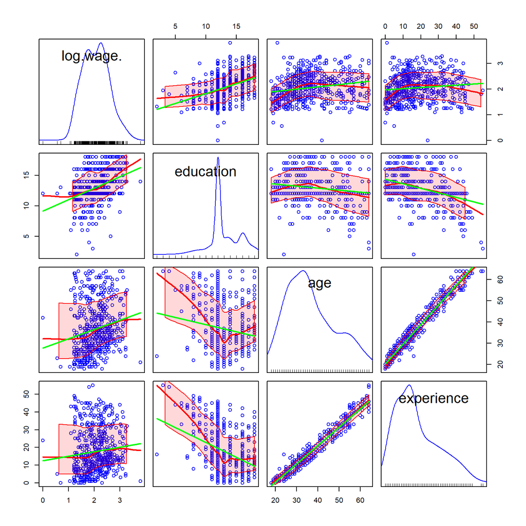

```r
##
## Scatterplot matrix for log(wage), education, age, experience
##

library(car)
library(AER)
data("CPS1985", package = "AER")
rownames(CPS1985) <- 1:nrow(CPS1985)

scatterplotMatrix(~log(wage)+education+age+experience,
                  data=CPS1985, diagonal="density", span=.75,
                  smooth=list(span=0.5, lty.smooth=1, col.smooth="red", col.var="red"),
                  regLine=list(col="green"))
```

The scatterplot matrix above displays the pairwise relationships among `log(wage)`, `education`, `age`, and `experience`.

The most striking pattern is found in the panel for **`age` versus `experience`**: the data points form an extremely tight, nearly perfect positive linear band, with both the regression line (green) and the smooth curve (red) almost completely overlapping. This near-perfect linearity is not a coincidence — according to the dataset documentation, `experience` is defined as `experience = age − education − 6`, meaning that once `age` and `education` are known, `experience` is entirely determined. As a result, **`age` and `experience` are expected to be severely multicollinear**.

The panel for **`education` versus `experience`** also shows a moderate negative linear relationship, which is again consistent with the formula above: higher education tends to reduce years of work experience, all else being equal. This suggests that **`education` and `experience` have a small amount of collinearity**, though less extreme than the `age`–`experience` pair.

In contrast, `log(wage)` shows only weak to moderate associations with the other three variables, with considerable scatter around both the regression line and the smooth curve. Therefore, `log(wage)` is not expected to be a source of multicollinearity.

In summary, based on both the variable definition and the visual evidence from the scatterplot matrix, **`age` and `experience` are the most problematic multicollinear pair**, and including both in the same regression model is likely to cause serious estimation problems, which will be confirmed in parts [b] and [c].

[b] Estimate the model `log(wage)~education+experience` and calculate the variance inflation factors. Fully interpret the estimated model and the **VIFs**. (0.5 point)

*Show the R code, results, and discussion here.*

### 4-b answer

```r
##
# Estimate log(wage)~education+experience, then calculate VIF
##

mod.b <- lm(log(wage) ~ education + experience, data=CPS1985)
summary(mod.b)
```

```
Call:
lm(formula = log(wage) ~ education + experience, data = CPS1985)

Residuals:
     Min       1Q   Median       3Q      Max
-2.03371 -0.33057  0.04223  0.31897  1.83976

Coefficients:
            Estimate Std. Error t value Pr(>|t|)
(Intercept) 0.594169   0.124428   4.775 2.33e-06 ***
education   0.096414   0.008310  11.603  < 2e-16 ***
experience  0.011774   0.001756   6.707 5.10e-11 ***
---
Signif. codes:  0 '***' 0.001 '**' 0.01 '*' 0.05 '.' 0.1 ' ' 1

Residual standard error: 0.4695 on 531 degrees of freedom
Multiple R-squared:  0.2115,    Adjusted R-squared:  0.2085
F-statistic: 71.21 on 2 and 531 DF,  p-value: < 2.2e-16
```

```r
cat("\nVariance Inflation Factors:\n")
```

```
Variance Inflation Factors:
```

```r
print(car::vif(mod.b))
```

```
 education experience
  1.142049   1.142049
```

The estimated model is:

$$\widehat{\log(\text{wage})} = 0.594 + 0.096 \cdot \text{education} + 0.012 \cdot \text{experience}$$

**Interpretation of the regression coefficients:**

The intercept of 0.594 represents the estimated log-wage when both education and experience are zero, which is not practically meaningful but is necessary to anchor the regression plane.

The coefficient for `education` is 0.096, which means that holding `experience` constant, each additional year of education is associated with approximately a 9.6% increase in wage. This effect is highly significant (*t* = 11.603, *p* < 0.001), indicating that education is a strong predictor of wages.

The coefficient for `experience` is 0.012, meaning that holding `education` constant, each additional year of work experience is associated with approximately a 1.2% increase in wage. This effect is also highly significant (*t* = 6.707, *p* < 0.001).

**Overall model fit:**

The adjusted R² is 0.209, meaning the model explains about 20.9% of the variation in log-wages. While this is modest, the global F-test is highly significant (*F* = 71.21, *p* < 0.001), confirming that the two predictors jointly explain a statistically meaningful portion of the variation in wages.

**Interpretation of VIFs:**

Both `education` and `experience` have a VIF of approximately 1.14, which is extremely close to 1. Since a VIF of 1 indicates no multicollinearity and a VIF above 10 is generally considered problematic, these values suggest that **multicollinearity is not a concern in this two-variable model**. Even though `education` and `experience` are related through the formula `experience = age − education − 6`, without `age` being included in the model, the problematic part of the linear dependency is not activated. Therefore, the regression coefficients in this model can be interpreted with confidence.

[c] Estimate the augmented model `log(wage)~education+experience+age` and show the output. (0.75 points)

Address the following points:

- What do the **VIFs** of this model tell you?
- What happened to the significances of the *t*-tests for the estimated regression parameters of the augmented model and why?
- Why does the global *F*-test still remain significant?

*Show the R code, results, and discussion here.*

### 4-c answer

```r
##
## Estimate augmented model log(wage)~education+experience+age, then VIF
##

mod.c <- lm(log(wage) ~ education + experience + age, data=CPS1985)
summary(mod.c)
```

```
Call:
lm(formula = log(wage) ~ education + experience + age, data = CPS1985)

Residuals:
     Min       1Q   Median       3Q      Max
-2.03367 -0.33094  0.04165  0.31958  1.84066

Coefficients:
            Estimate Std. Error t value Pr(>|t|)
(Intercept)  0.84480    0.71884   1.175    0.240
education    0.13805    0.11791   1.171    0.242
experience   0.05353    0.11796   0.454    0.650
age         -0.04173    0.11786  -0.354    0.723

Residual standard error: 0.4699 on 530 degrees of freedom
Multiple R-squared:  0.2117,    Adjusted R-squared:  0.2072
F-statistic: 47.44 on 3 and 530 DF,  p-value: < 2.2e-16
```

```r
cat("\nVariance Inflation Factors:\n")
```

```
Variance Inflation Factors:
```

```r
print(car::vif(mod.c))
```

```
 education experience        age
  229.5738  5147.9190  4611.4008
```

The estimated model is:

$$\widehat{\log(\text{wage})} = 0.845 + 0.138 \cdot \text{education} + 0.054 \cdot \text{experience} - 0.042 \cdot \text{age}$$

**VIFs of the augmented model:**

After adding `age` into the model, the VIFs increase dramatically. The VIF for `education` rises to 229.57, for `experience` to 5,147.92, and for `age` to 4,611.40. All three values are far above the commonly used threshold of 10, indicating **extremely severe multicollinearity**. This is a direct consequence of the near-perfect linear relationship among these three variables: since `experience` is defined as `age − education − 6` in the dataset documentation, including all three variables simultaneously means the model is essentially trying to use redundant information. The VIF for `experience` being the largest reflects that it is the variable most perfectly explained by the other two.

**What happened to the t-tests and why:**

Comparing the two models reveals a striking contrast. In the base model `log(wage) ~ education + experience`, both predictors were highly significant (`education`: *t* = 11.603, *p* < 0.001; `experience`: *t* = 6.707, *p* < 0.001). However, after adding `age` into the augmented model, **none of the three predictors remain significant** — `education` (*t* = 1.171, *p* = 0.242), `experience` (*t* = 0.454, *p* = 0.650), and `age` (*t* = −0.354, *p* = 0.723) all fail to reach significance.

This happens because severe multicollinearity **inflates the standard errors** of the estimated coefficients enormously. When predictors are nearly linearly dependent, the model cannot distinguish their individual contributions — it is like trying to figure out which of three nearly identical witnesses is telling the truth. As a result, the estimated coefficients become highly unstable and their standard errors blow up, making the *t*-statistics too small to be significant even though the predictors genuinely affect wages.

**Why the global F-test remains significant:**

Despite the individual *t*-tests all being insignificant, the global F-test remains highly significant (*F* = 47.44, *p* < 0.001). This is because the F-test evaluates whether **all predictors jointly** explain a significant portion of the variation in `log(wage)` — and they do. Multicollinearity does not destroy the collective explanatory power of the predictors; it only makes it impossible to separate their individual contributions. In other words, the model as a whole still knows that education, experience, and age together matter for wages — it just cannot tell us which one deserves the credit. This contrast between insignificant *t*-tests and a significant F-test is in fact a **classic symptom of severe multicollinearity**.

## Task 5: Refined model specification (1.5 point)

[a] Estimate the model `log(wage)~education+experience+gender+occupation+union` and fully interpret the estimated regression model. (1 point)

*Show the R code, results, and discussion here.*

### 5-a answer

```r
##
## Estimate log(wage)~education+experience+gender+occupation+union
##

mod.5a <- lm(log(wage)~education+experience+gender+occupation+union, data=CPS1985)
summary(mod.5a)
```

```
Call:
lm(formula = log(wage) ~ education + experience + gender + occupation +
    union, data = CPS1985)

Residuals:
    Min      1Q  Median      3Q     Max
-2.3073 -0.2845 -0.0025  0.3027  1.7950

Coefficients:
                      Estimate Std. Error t value Pr(>|t|)
(Intercept)           0.972050   0.132893   7.315 9.74e-13 ***
education             0.072296   0.009931   7.280 1.23e-12 ***
experience            0.010775   0.001670   6.454 2.49e-10 ***
genderfemale         -0.203606   0.041860  -4.864 1.52e-06 ***
occupationtechnical   0.161965   0.069502   2.330  0.02017 *
occupationservices   -0.198521   0.061204  -3.244  0.00126 **
occupationoffice     -0.018791   0.063715  -0.295  0.76817
occupationsales      -0.150690   0.082108  -1.835  0.06703 .
occupationmanagement  0.209102   0.076316   2.740  0.00635 **
unionyes              0.216589   0.051117   4.237 2.68e-05 ***
---
Signif. codes:  0 '***' 0.001 '**' 0.01 '*' 0.05 '.' 0.1 ' ' 1

Residual standard error: 0.4323 on 524 degrees of freedom
Multiple R-squared:  0.3404,    Adjusted R-squared:  0.3291
F-statistic: 30.05 on 9 and 524 DF,  p-value: < 2.2e-16
```

```r
cbind(Estimate=coef(mod.5a), confint(mod.5a))   # coefficient estimates with 95% CI
```

```
                        Estimate        2.5 %      97.5 %
(Intercept)           0.97204997  0.710981374  1.23311856
education             0.07229559  0.052786020  0.09180516
experience            0.01077474  0.007494942  0.01405454
genderfemale         -0.20360569 -0.285839613 -0.12137177
occupationtechnical   0.16196490  0.025428665  0.29850114
occupationservices   -0.19852138 -0.318756579 -0.07828618
occupationoffice     -0.01879082 -0.143959968  0.10637833
occupationsales      -0.15069041 -0.311991603  0.01061078
occupationmanagement  0.20910207  0.059178716  0.35902542
unionyes              0.21658944  0.116169562  0.31700932
```

The estimated model is:

$$\widehat{\log(\text{wage})} = 0.972 + 0.072\cdot\text{education} + 0.011\cdot\text{experience} - 0.204\cdot\mathbb{gender}_{\text{female}} + 0.162\cdot\mathbb{occupation}_{\text{technical}} - 0.199\cdot\mathbb{occupation}_{\text{services}} - 0.019\cdot\mathbb{occupation}_{\text{office}} - 0.151\cdot\mathbb{occupation}_{\text{sales}} + 0.209\cdot\mathbb{occupation}_{\text{management}} + 0.217\cdot\mathbb{union}_{\text{yes}}$$

**Interpretation of continuous predictors:**

The coefficient for `education` is 0.072, meaning that holding all other variables constant, each additional year of education is associated with approximately a 7.2% increase in wage (*t* = 7.280, *p* < 0.001). Similarly, each additional year of work `experience` is associated with approximately a 1.1% increase in wage (*t* = 6.454, *p* < 0.001). Both effects remain highly significant after controlling for gender, occupation, and union status.

**Interpretation of `gender`:**

The reference category is `male`. The coefficient for `female` is −0.204 (*t* = −4.864, *p* < 0.001), indicating that female workers earn approximately 20.4% less than male workers with the same education, experience, occupation, and union status. The 95% confidence interval [−0.286, −0.121] does not include zero, confirming this gender wage gap is statistically significant.

**Interpretation of `occupation`:**

The reference category is `worker` (tradesperson or assembly line worker). Compared to workers and holding all other variables constant, `technical` employees earn approximately 16.2% more (*p* = 0.020), `management` employees earn approximately 20.9% more (*p* = 0.006), and `services` employees earn approximately 19.9% less (*p* = 0.001). The coefficients for `office` (*p* = 0.768) and `sales` (*p* = 0.067) are not statistically significant at the 5% level, and their 95% confidence intervals both include zero, suggesting that these two groups do not differ significantly from `worker` in terms of wages after controlling for other variables.

**Interpretation of `union`:**

The reference category is non-union (`no`). Workers who are union members earn approximately 21.7% more than non-union workers, holding everything else constant (*t* = 4.237, *p* < 0.001). The 95% confidence interval [0.116, 0.317] confirms this union wage premium is clearly significant.

**Overall model fit:**

The adjusted R² is 0.329, meaning the model explains about 32.9% of the variation in log-wages, which is a noticeable improvement over the base model in Task 4[b] (adjusted R² = 0.209). The global F-test is highly significant (*F* = 30.05, *p* < 0.001), confirming that the predictors jointly explain a meaningful portion of wage variation.

[b] Test whether the factor `occupation` is significant and if necessary, refine the model specification accordingly. (0.5 points)

*Show the R code, results, and discussion here.*

### 5-b answer

```r
##
## Test whether occupation is significant using partial F-test
##

## Restricted model: remove occupation
mod.5b <- lm(log(wage)~education+experience+gender+union, data=CPS1985)

## Partial F-test: compare restricted vs full model
anova(mod.5b, mod.5a)        # H0: all occupation coefficients = 0
```

```
Analysis of Variance Table

Model 1: log(wage) ~ education + experience + gender + union
Model 2: log(wage) ~ education + experience + gender + occupation + union
  Res.Df     RSS Df Sum of Sq      F    Pr(>F)
1    529 105.092
2    524  97.915  5    7.1769 7.6816 5.535e-07 ***
---
Signif. codes:  0 '***' 0.001 '**' 0.01 '*' 0.05 '.' 0.1 ' ' 1
```

```r
## Type II ANOVA: individual contribution of each factor
car::Anova(mod.5a)
```

```
Anova Table (Type II tests)

Response: log(wage)
           Sum Sq  Df F value    Pr(>F)
education   9.903   1 52.9948 1.232e-12 ***
experience  7.783   1 41.6509 2.488e-10 ***
gender      4.421   1 23.6582 1.524e-06 ***
occupation  7.177   5  7.6816 5.535e-07 ***
union       3.355   1 17.9531 2.675e-05 ***
Residuals  97.915 524
---
Signif. codes:  0 '***' 0.001 '**' 0.01 '*' 0.05 '.' 0.1 ' ' 1
```

To test whether `occupation` as a whole is a significant predictor of log-wages, a partial F-test is conducted by comparing the restricted model (without `occupation`) against the full model (with `occupation`). The null hypothesis is that all five occupation coefficients are simultaneously equal to zero: $H_0: \beta_{\text{technical}} = \beta_{\text{services}} = \beta_{\text{office}} = \beta_{\text{sales}} = \beta_{\text{management}} = 0$.

The partial F-test yields *F* = 7.682 with 5 and 524 degrees of freedom (*p* < 0.001). Since the p-value is far below the 0.05 significance level, we **reject the null hypothesis** and conclude that `occupation` jointly contributes significant explanatory power to the model. This conclusion is further confirmed by the Type II ANOVA table from `car::Anova()`, which shows that `occupation` has a sum of squares of 7.177 with an associated F-statistic of 7.682 (*p* < 0.001), consistent with the partial F-test result.

Since `occupation` is statistically significant as a whole, **there is no justification to remove it from the model**, even though the individual t-tests for `office` and `sales` were not significant at the 5% level. The partial F-test evaluates the joint contribution of the entire factor, which is the appropriate test for a categorical variable with multiple levels. Therefore, the full model `log(wage) ~ education + experience + gender + occupation + union` is retained as the final specification.

## Task 6: Case statistics of the final model (1.5 points)

[a] Generate the following plots and interpret them for your final model. (1 point)

- Identify the two most extreme observations with a `car::qqPlot( )` and interpret the plot.
- Identify potential extreme observations with a `car::influenceIndexPlot( )` and interpret the plots.

*Show the R code, results, and discussion here.*

### 6-a answer

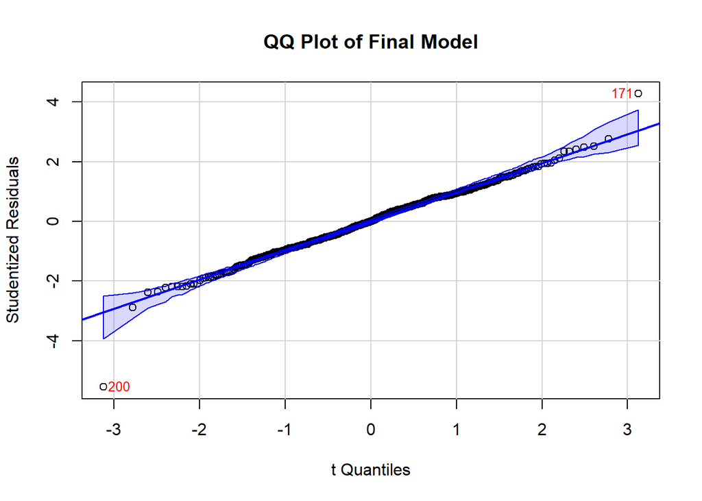

```
[1] 171 200
```

```r
##
## QQ plot and influence index plot for final model (mod.5a)
##

## QQ plot: identify two most extreme observations
car::qqPlot(mod.5a, id=list(method="y", n=2, cex=0.8, col="red"),
            ylab="Studentized Residuals",
            main="QQ Plot of Final Model")
```

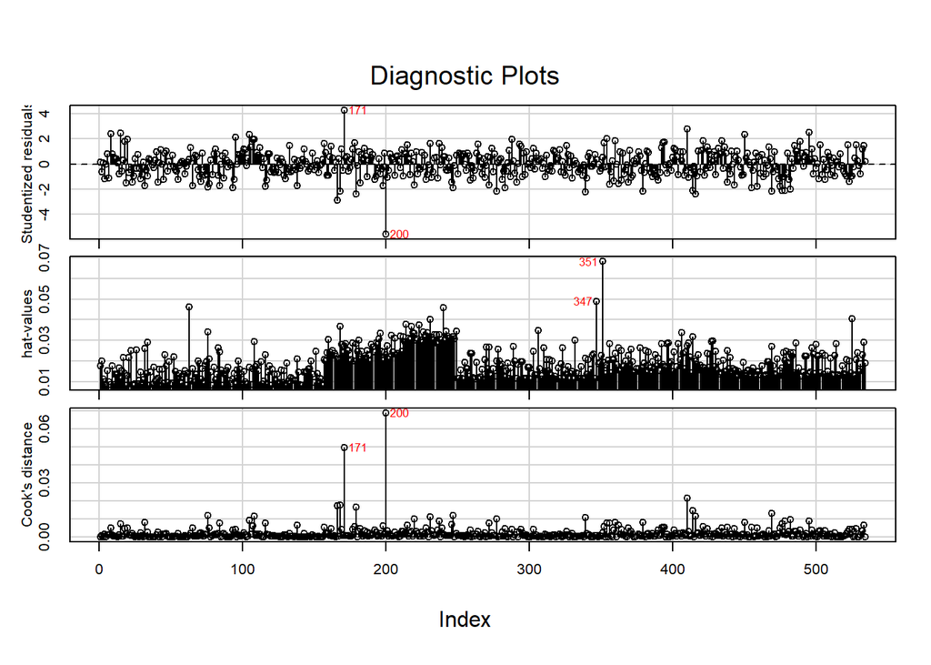

```r
## Influence index plot: identify potential extreme observations
car::influenceIndexPlot(mod.5a, vars=c("studentized", "hat", "Cook"),
                        id=list(method="y", n=2, cex=0.8, col="red"))
```

**QQ Plot:**

The QQ plot compares the studentized residuals of the final model against the theoretical quantiles of a t-distribution. Overall, the majority of observations follow the diagonal reference line closely and remain within the 95% confidence band (shaded blue area), suggesting that the normality assumption of the residuals is reasonably satisfied for most observations.

**Influence Index Plot:**

The influence index plot displays three diagnostic measures for all observations. In the **studentized residuals** panel, observations 171 and 200 again stand out clearly, with absolute values exceeding 4, which is far beyond the commonly used threshold of ±2. This confirms that both are strong outliers in terms of their residuals.

In the **hat-values** panel, observations 347 and 351 show the highest leverage, meaning their predictor values are unusually far from the centre of the data. However, high leverage alone does not necessarily make an observation influential.

In the **Cook’s distance** panel, observation **200** has the largest Cook’s distance, followed by observation **171**, indicating that these two observations have the greatest overall influence on the estimated regression coefficients. Together, the three panels consistently point to observations **171** and **200** as the most problematic cases in the dataset, warranting further inspection in Task 6[b].

[b] Inspect the two most extreme observations in the data-frame by examining their records. (0.5 points)

- Discuss their attributes and argue if they are representative of the underlying population.
- Drop them from the data-frame and show your code for doing so.

*Show the R code, and discussion here.*

### 6-b answer

```r
##
## Inspect and remove the two most extreme observations (row 171 and 200)
##

## Inspect the two extreme observations
cat("=== Extreme Observations: Row 171 and 200 ===\n")
```

```
=== Extreme Observations: Row 171 and 200 ===
```

```r
print(CPS1985[c(171, 200), ])
```

```
    wage education experience age ethnicity region gender occupation sector
171 44.5        14          1  21      cauc  other female management  other
200  1.0        12         24  42      cauc  other   male management  other
    union married
171    no      no
200    no     yes
```

```r
## Remove the two extreme observations
CPS1985.clean <- subset(CPS1985, !rownames(CPS1985) %in% c("171", "200"))
cat("\nOriginal nrow:", nrow(CPS1985), "\n")
```

```
Original nrow: 534
```

```r
cat("Cleaned  nrow:", nrow(CPS1985.clean), "\n")
```

```
Cleaned  nrow: 532
```

The two most extreme observations are inspected by examining their records directly from the data-frame:

| Row | wage | education | experience | age | gender | occupation | union |
| --- | --- | --- | --- | --- | --- | --- | --- |
| 171 | **44.50** | 14 | 1 | 21 | female | management | no |
| 200 | **1.00** | 12 | 24 | 42 | male | management | no |

**Observation 171** is a 21-year-old female in a management position with only 1 year of work experience, yet earning $44.50 per hour — an exceptionally high wage that is far above the typical range for someone with so little experience. This combination of very young age, minimal experience, and extremely high managerial wage is highly unusual and is difficult to consider representative of the general working population. It is likely either a data entry error or an extraordinary outlier case.

**Observation 200** is a 42-year-old male in a management position with 24 years of experience, yet earning only $1.00 per hour — an implausibly low wage for someone with such extensive experience in management. A wage of $1.00 per hour is essentially at or below minimum wage, which is inconsistent with a management occupation. This observation is almost certainly a data recording error or a highly atypical case that is not representative of the underlying population. Since both observations have implausible combinations of attributes that are unlikely to represent the true population of wage earners, they are removed from the data-frame before further analysis. After removal, the cleaned data-frame `CPS1985.clean` contains 532 observations, down from the original 534.